# Project1

arnela82

4/29/2020

##This is my submission for Reproducible Research Course Project 1

###Loading and preprocessing the data

```r
activity<-read.csv("C:/Users/Arnela/Desktop/coursera/activity.csv")
summary(activity)
```

```
##      steps            date              interval
##  Min.   :  0.00   Length:17568       Min.   :   0.0
##  1st Qu.:  0.00   Class :character   1st Qu.: 588.8
##  Median :  0.00   Mode  :character   Median :1177.5
##  Mean   : 37.38                      Mean   :1177.5
##  3rd Qu.: 12.00                      3rd Qu.:1766.2
##  Max.   :806.00                      Max.   :2355.0
##  NA's   :2304
```

```r
#Some information about the variables
str(activity)
```

```
## 'data.frame':    17568 obs. of  3 variables:
##  $ steps   : int  NA NA NA NA NA NA NA NA NA NA ...
##  $ date    : chr  "2012-10-01" "2012-10-01" "2012-10-01" "2012-10-01" ...
##  $ interval: int  0 5 10 15 20 25 30 35 40 45 ...
```

```r
#Some information about the variables
names(activity)
```

```
## [1] "steps"    "date"     "interval"
```

```r
#Some information about the variables
head(activity)
```

```
##   steps       date interval
## 1    NA 2012-10-01        0
## 2    NA 2012-10-01        5
## 3    NA 2012-10-01       10
## 4    NA 2012-10-01       15
## 5    NA 2012-10-01       20
## 6    NA 2012-10-01       25
```

###Total number of steps per day *1.We calculate the total number of steps taken per day*

```r
StepsPerDay<-aggregate(steps~date,data = activity,sum, na.rm=TRUE)
colnames(StepsPerDay)<-c("Date","Steps")
StepsPerDay
```

```
##          Date Steps
## 1  2012-10-02   126
## 2  2012-10-03 11352
## 3  2012-10-04 12116
## 4  2012-10-05 13294
## 5  2012-10-06 15420
## 6  2012-10-07 11015
## 7  2012-10-09 12811
## 8  2012-10-10  9900
## 9  2012-10-11 10304
## 10 2012-10-12 17382
## 11 2012-10-13 12426
## 12 2012-10-14 15098
## 13 2012-10-15 10139
## 14 2012-10-16 15084
```

[output cut: 39 more lines]

*2.Histogram of the total number od steps taken each day*

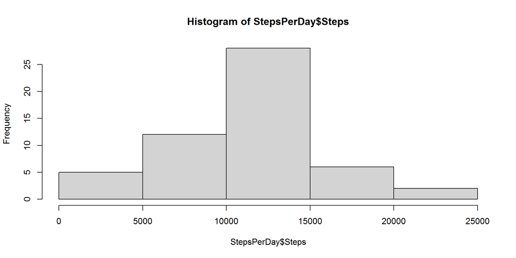

```r
hist(StepsPerDay$Steps)
```

*3.Mean and median of total number of steps taken per day*

```r
#mean
mean(StepsPerDay$Steps,na.rm = TRUE)
```

```
## [1] 10766.19
```

```r
#median
median(StepsPerDay$Steps,na.rm = TRUE)
```

```
## [1] 10765
```

###Averagre daily activity pattern

*1.Time series plot of the 5 minute interval and averaged number of steps taken averaged across all days*

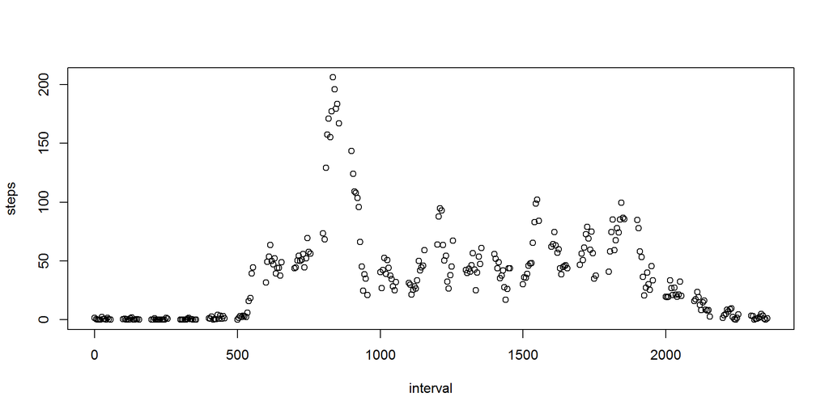

```r
#create table with steps per time
StepsPerInterval<-aggregate(steps~interval,data = activity,mean,na.rm=TRUE)
#variable time
StepsPerInterval$time<-StepsPerInterval$interval/100
plot(steps~interval,data = StepsPerInterval)
```

*2.5-minute interval with the max number of steps*

```r
#The 5-minute interval accross all day containig the maximum nuber od steps is stored in variable MaxNbSteps
MaxNbSteps<-StepsPerInterval[which.max(StepsPerInterval$steps),]$interval
MaxNbSteps
```

```
## [1] 835
```

###Imputing missing values *1.Total number od missig values ( totalMV )*

```r
totalVM<-sum(is.na(activity$steps))
totalVM
```

```
## [1] 2304
```

*2.Replacing missing values*

```r
getMeanStepsPerInterval<-function(interval){
  StepsPerInterval[StepsPerInterval$interval==interval,]$steps
}
```

*3.Create a new dataset that is equal to the original dataset but with the missing data filled in*

```r
#new dataset is activityFull
activityFull<-activity
for(i in 1:nrow(activityFull)){
  if(is.na(activityFull[i,]$steps)){
    activityFull[i,]$steps<-getMeanStepsPerInterval(activityFull[i,]$interval)}
}
```

*4.Histogram of the total number of steps taken each day with missing data filled in*

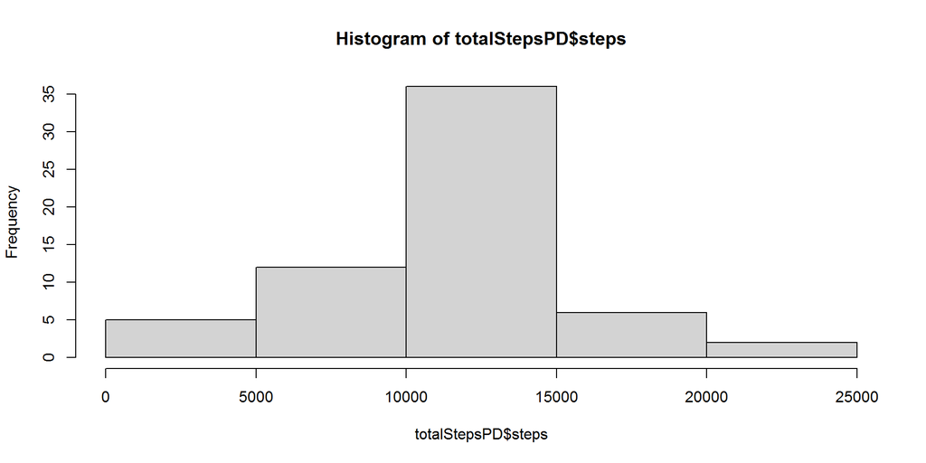

```r
totalStepsPD<-aggregate(steps~date,data=activityFull,sum)
hist(totalStepsPD$steps)
```

*4.a Caltulate and report the mean and median total number of steps taken per day*

```r
#mean
mean(totalStepsPD$steps)
```

```
## [1] 10766.19
```

```r
#median
median(totalStepsPD$steps)
```

```
## [1] 10766.19
```

```r
activityFull$date<-as.Date(activityFull$date, format = "%Y-%m-%d")
activityFull$day<-weekdays(activityFull$date)
for (i in 1:nrow(activityFull)) {
  if (activityFull[i,]$day %in% c("Saturday","Sunday")){
    activityFull[i,]$day<-"weekday"
  }
}
```

[figure not shown]

[figure not shown]

[figure not shown]

[figure not shown]

```r
stepsByday<-aggregate(activityFull$steps~activityFull$interval+activityFull$day, activityFull,mean)
names(stepsByday)<-c("interval","day","steps")
library(lattice)
xyplot(steps~interval|day, stepsByday, type="1",layout=c(1,2),xlab="Interval",ylab = "Number of steps")
```